# Topic 1-04: Get pathways from Reactome

Zuguang Gu z.gu@dkfz.de

2025-05-22

Reactome is another popular pathway database. It organizes pathways in a hierarchical manner, which contains pathways and sub pathways or pathway components. The up-to-date pathway data can be direclty found at https://reactome.org/download-data (Mapping Files -> Identifier mapping files -> NCBI to All pathways)

## reactome.db

There is a **reactome.db** on Bioconductor.

The version of the data:

```r
library(reactome.db)
reactome.db
```

```
## ReactomeDb object:
## | DBSCHEMA: REACTOME_DB
## | DBSCHEMAVERSION: 89
## | SOURCENAME: Reactome
## | SOURCEURL: https://reactome.org/download/current/databases/gk_current.sql.gz
## | SOURCEDATE: 19997
## | Supporting package: AnnotationDbi
## | Db type: ReactomeDb
```

```
##
## Please see: help('select') for usage information
```

In it, the important objects are

- `reactomePATHID2EXTID` contains mappings between reacotme pathway IDs and gene entrez IDs
- `reactomePATHID2NAME` contains pathway names

```r
library(reactome.db)
tb = toTable(reactomePATHID2EXTID)
head(tb)
```

```
##           DB_ID gene_id
## 1  R-HSA-109582       1
## 2  R-HSA-114608       1
## 3  R-HSA-168249       1
## 4  R-HSA-168256       1
## 5 R-HSA-6798695       1
## 6   R-HSA-76002       1
```

```r
p2n = toTable(reactomePATHID2NAME)
head(p2n)
```

```
##           DB_ID
## 1 R-BTA-1971475
## 2 R-BTA-1369062
## 3  R-BTA-382556
## 4 R-BTA-9033807
## 5  R-BTA-418592
## 6  R-BTA-392170
##                                                                     path_name
## 1 Bos taurus: A tetrasaccharide linker sequence is required for GAG synthesis
## 2                           Bos taurus: ABC transporters in lipid homeostasis
## 3                          Bos taurus: ABC-family proteins mediated transport
## 4                                    Bos taurus: ABO blood group biosynthesis
## 5                       Bos taurus: ADP signalling through P2Y purinoceptor 1
## 6                      Bos taurus: ADP signalling through P2Y purinoceptor 12
```

In the previous code, we use the function `toTable()` to retrieve the data as a data frame. You can also try `as.list()` on the two objects and compare the output.

Reactome contains pathway for multiple organisms. In the reactome ID, teh second section contains the organism, e.g. in previous output `HSA`.

```r
sort(table( gsub("^R-(\\w+)-\\d+$", "\\1", p2n[, 1]) ))
```

```
##
##  MTU  PFA  SCE  SPO  DDI  CEL  DRE  XTR  DME  CFA  SSC  BTA  RNO  GGA  MMU  HSA
##   13  641  855  872 1035 1366 1374 1520 1528 1714 1734 1742 1750 1762 1762 2711
```

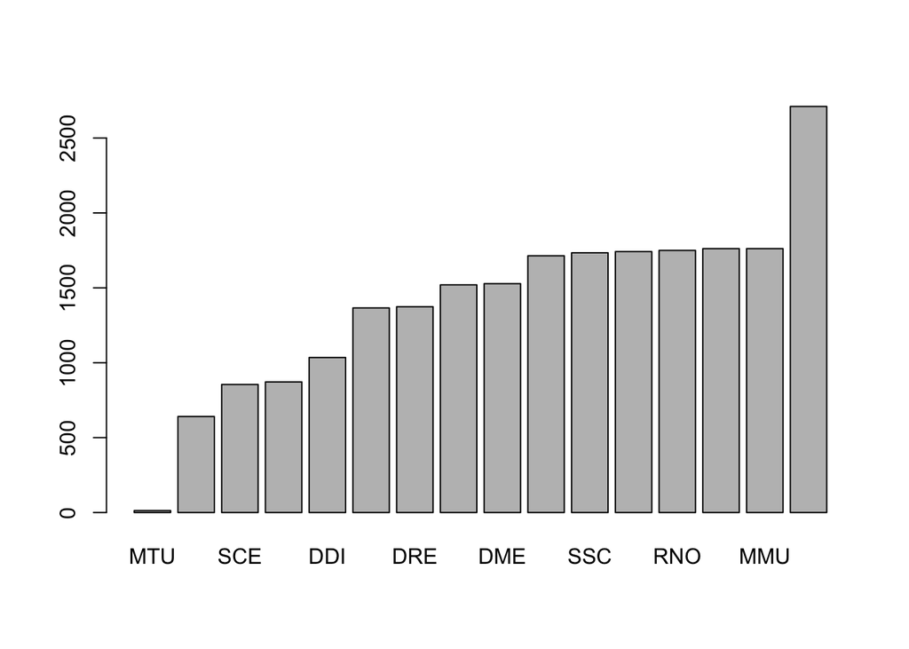

```r
barplot(sort(table( gsub("^R-(\\w+)-\\d+$", "\\1", p2n[, 1]) )))
```

## Directly get data from the database

If you are not sure whether **reactome.db** provides the most up-to-date data, we can directly process the original data fro reactome database.

```r
download.file("https://reactome.org/download/current/NCBI2Reactome_All_Levels.txt", destfile = "NCBI2Reactome_All_Levels.txt")
tb = read.table("NCBI2Reactome_All_Levels.txt", sep = "\t", comment.char = "")
head(tb)
```

```
##   V1            V2                                                  V3
## 1  1  R-HSA-109582  https://reactome.org/PathwayBrowser/#/R-HSA-109582
## 2  1  R-HSA-114608  https://reactome.org/PathwayBrowser/#/R-HSA-114608
## 3  1  R-HSA-168249  https://reactome.org/PathwayBrowser/#/R-HSA-168249
## 4  1  R-HSA-168256  https://reactome.org/PathwayBrowser/#/R-HSA-168256
## 5  1 R-HSA-6798695 https://reactome.org/PathwayBrowser/#/R-HSA-6798695
## 6  1   R-HSA-76002   https://reactome.org/PathwayBrowser/#/R-HSA-76002
##                                               V4  V5           V6
## 1                                     Hemostasis TAS Homo sapiens
## 2                        Platelet degranulation  TAS Homo sapiens
## 3                           Innate Immune System TAS Homo sapiens
## 4                                  Immune System TAS Homo sapiens
## 5                       Neutrophil degranulation TAS Homo sapiens
## 6 Platelet activation, signaling and aggregation TAS Homo sapiens
```

Restrict to human

```r
tb = tb[tb[, 6] == "Homo sapiens", ]
```

The gene sets

```r
gs = split(tb[, 1], tb[, 2])
```

It is better to ensure Entrez IDs are stored as characters.

```r
gs = lapply(gs, as.character)
```

Pathway names:

```r
p2n = unique(tb[, c(2, 4)])
```

## Practice

#### Practice 1

Make the distribution of the numbers of genes in Reactome pathways (use human).

Print the names of pathways with numbers of genes > 2000.

#### Solution

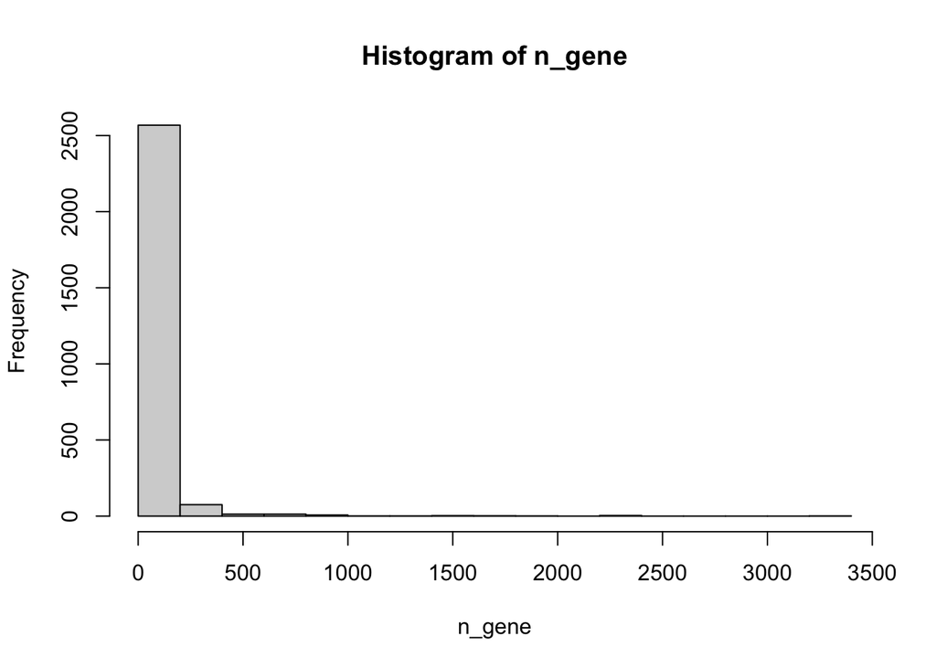

```r
tb = toTable(reactomePATHID2EXTID)
tb = tb[grep("-HSA-", tb[, 1]), ]
n_gene = table(tb[, 1])
hist(n_gene)
```

Making the intervals smaller is better:

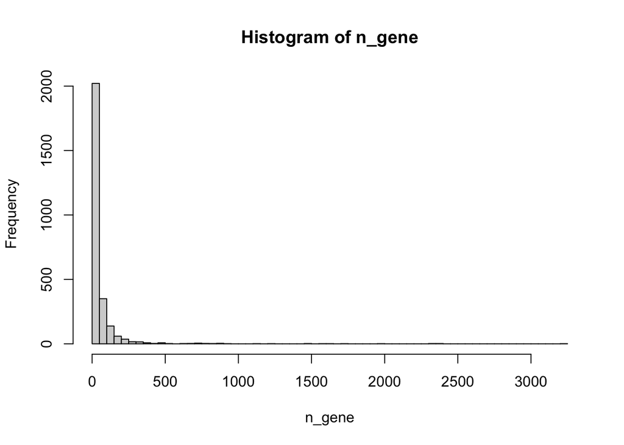

```r
hist(n_gene, nc = 100)
```

Pathways more than 2000 genes:

```r
n_gene[n_gene > 2000]
```

```
##
## R-HSA-1430728  R-HSA-162582 R-HSA-1643685  R-HSA-168256  R-HSA-392499
##          2347          3231          2304          2394          2387
```

Their names:

```r
p2n = toTable(reactomePATHID2NAME)
p2n[p2n[, 1] %in% names(n_gene[n_gene > 2000]), ]
```

```
##               DB_ID                            path_name
## 11250 R-HSA-1643685                Homo sapiens: Disease
## 11665  R-HSA-168256          Homo sapiens: Immune System
## 11905 R-HSA-1430728             Homo sapiens: Metabolism
## 11923  R-HSA-392499 Homo sapiens: Metabolism of proteins
## 12694  R-HSA-162582    Homo sapiens: Signal Transduction
```

If you go to https://reactome.org/PathwayBrowser/, these big pathways correspond to the pathway clusters on the top level.